# Risk Factor Analysis

## Outcome Variable

**Outcome Variable:** sstunted

## Predictor Variables

**Intervention Variable:** birthlen

**Adjustment Set:**

unadjusted

## Stratifying Variables

The analysis was stratified on these variable(s):

- agecat
- studyid
- country

## Data Summary

| agecat | studyid | country | A | n | nA | nAY0 | nAY1 |
| --- | --- | --- | --- | --- | --- | --- | --- |
| Birth | ki0047075b-MAL-ED | BANGLADESH | >=0 | 257 | 39 | 39 | 0 |
| Birth | ki0047075b-MAL-ED | BANGLADESH | <-3 | 257 | 9 | 0 | 9 |
| Birth | ki0047075b-MAL-ED | BANGLADESH | [-3–2) | 257 | 38 | 38 | 0 |
| Birth | ki0047075b-MAL-ED | BANGLADESH | [-2–1) | 257 | 83 | 83 | 0 |
| Birth | ki0047075b-MAL-ED | BANGLADESH | [-1-0) | 257 | 88 | 88 | 0 |
| Birth | ki0047075b-MAL-ED | BRAZIL | >=0 | 191 | 44 | 44 | 0 |
| Birth | ki0047075b-MAL-ED | BRAZIL | <-3 | 191 | 8 | 0 | 8 |
| Birth | ki0047075b-MAL-ED | BRAZIL | [-3–2) | 191 | 13 | 13 | 0 |
| Birth | ki0047075b-MAL-ED | BRAZIL | [-2–1) | 191 | 48 | 48 | 0 |
| Birth | ki0047075b-MAL-ED | BRAZIL | [-1-0) | 191 | 78 | 78 | 0 |
| Birth | ki0047075b-MAL-ED | INDIA | >=0 | 206 | 34 | 34 | 0 |
| Birth | ki0047075b-MAL-ED | INDIA | <-3 | 206 | 7 | 0 | 7 |
| Birth | ki0047075b-MAL-ED | INDIA | [-3–2) | 206 | 26 | 26 | 0 |
| Birth | ki0047075b-MAL-ED | INDIA | [-2–1) | 206 | 66 | 66 | 0 |
| Birth | ki0047075b-MAL-ED | INDIA | [-1-0) | 206 | 73 | 73 | 0 |
| Birth | ki0047075b-MAL-ED | NEPAL | >=0 | 173 | 45 | 45 | 0 |
| Birth | ki0047075b-MAL-ED | NEPAL | <-3 | 173 | 6 | 0 | 6 |
| Birth | ki0047075b-MAL-ED | NEPAL | [-3–2) | 173 | 12 | 12 | 0 |
| Birth | ki0047075b-MAL-ED | NEPAL | [-2–1) | 173 | 46 | 46 | 0 |
| Birth | ki0047075b-MAL-ED | NEPAL | [-1-0) | 173 | 64 | 64 | 0 |
| Birth | ki0047075b-MAL-ED | PERU | >=0 | 287 | 44 | 44 | 0 |
| Birth | ki0047075b-MAL-ED | PERU | <-3 | 287 | 8 | 0 | 8 |
| Birth | ki0047075b-MAL-ED | PERU | [-3–2) | 287 | 26 | 26 | 0 |
| Birth | ki0047075b-MAL-ED | PERU | [-2–1) | 287 | 94 | 94 | 0 |
| Birth | ki0047075b-MAL-ED | PERU | [-1-0) | 287 | 115 | 115 | 0 |
| Birth | ki0047075b-MAL-ED | SOUTH AFRICA | >=0 | 262 | 59 | 59 | 0 |
| Birth | ki0047075b-MAL-ED | SOUTH AFRICA | <-3 | 262 | 2 | 0 | 2 |
| Birth | ki0047075b-MAL-ED | SOUTH AFRICA | [-3–2) | 262 | 26 | 26 | 0 |
| Birth | ki0047075b-MAL-ED | SOUTH AFRICA | [-2–1) | 262 | 73 | 73 | 0 |
| Birth | ki0047075b-MAL-ED | SOUTH AFRICA | [-1-0) | 262 | 102 | 102 | 0 |

[output cut: 845 more lines]

The following strata were considered:

- agecat: 12 months, studyid: ki0047075b-MAL-ED, country: BANGLADESH
- agecat: 12 months, studyid: ki0047075b-MAL-ED, country: BRAZIL
- agecat: 12 months, studyid: ki0047075b-MAL-ED, country: INDIA
- agecat: 12 months, studyid: ki0047075b-MAL-ED, country: NEPAL
- agecat: 12 months, studyid: ki0047075b-MAL-ED, country: PERU
- agecat: 12 months, studyid: ki0047075b-MAL-ED, country: SOUTH AFRICA
- agecat: 12 months, studyid: ki0047075b-MAL-ED, country: TANZANIA, UNITED REPUBLIC OF
- agecat: 12 months, studyid: ki1000108-CMC-V-BCS-2002, country: INDIA
- agecat: 12 months, studyid: ki1000108-IRC, country: INDIA
- agecat: 12 months, studyid: ki1000109-EE, country: PAKISTAN
- agecat: 12 months, studyid: ki1000109-ResPak, country: PAKISTAN
- agecat: 12 months, studyid: ki1000304b-SAS-CompFeed, country: INDIA
- agecat: 12 months, studyid: ki1017093-NIH-Birth, country: BANGLADESH
- agecat: 12 months, studyid: ki1017093b-PROVIDE, country: BANGLADESH
- agecat: 12 months, studyid: ki1017093c-NIH-Crypto, country: BANGLADESH
- agecat: 12 months, studyid: ki1101329-Keneba, country: GAMBIA
- agecat: 12 months, studyid: ki1114097-CMIN, country: BRAZIL
- agecat: 12 months, studyid: ki1114097-CMIN, country: PERU
- agecat: 12 months, studyid: ki1114097-CONTENT, country: PERU
- agecat: 12 months, studyid: ki1119695-PROBIT, country: BELARUS
- agecat: 12 months, studyid: ki1126311-ZVITAMBO, country: ZIMBABWE
- agecat: 12 months, studyid: ki1135781-COHORTS, country: GUATEMALA
- agecat: 12 months, studyid: ki1135781-COHORTS, country: INDIA
- agecat: 12 months, studyid: ki1135781-COHORTS, country: PHILIPPINES
- agecat: 12 months, studyid: kiGH5241-JiVitA-3, country: BANGLADESH
- agecat: 12 months, studyid: kiGH5241-JiVitA-4, country: BANGLADESH
- agecat: 18 months, studyid: ki0047075b-MAL-ED, country: BANGLADESH
- agecat: 18 months, studyid: ki0047075b-MAL-ED, country: BRAZIL
- agecat: 18 months, studyid: ki0047075b-MAL-ED, country: INDIA
- agecat: 18 months, studyid: ki0047075b-MAL-ED, country: NEPAL
- agecat: 18 months, studyid: ki0047075b-MAL-ED, country: PERU
- agecat: 18 months, studyid: ki0047075b-MAL-ED, country: SOUTH AFRICA
- agecat: 18 months, studyid: ki0047075b-MAL-ED, country: TANZANIA, UNITED REPUBLIC OF
- agecat: 18 months, studyid: ki1000108-CMC-V-BCS-2002, country: INDIA
- agecat: 18 months, studyid: ki1000108-IRC, country: INDIA
- agecat: 18 months, studyid: ki1000109-EE, country: PAKISTAN
- agecat: 18 months, studyid: ki1000109-ResPak, country: PAKISTAN
- agecat: 18 months, studyid: ki1000304b-SAS-CompFeed, country: INDIA
- agecat: 18 months, studyid: ki1017093-NIH-Birth, country: BANGLADESH
- agecat: 18 months, studyid: ki1017093b-PROVIDE, country: BANGLADESH
- agecat: 18 months, studyid: ki1017093c-NIH-Crypto, country: BANGLADESH
- agecat: 18 months, studyid: ki1101329-Keneba, country: GAMBIA
- agecat: 18 months, studyid: ki1114097-CMIN, country: BRAZIL
- agecat: 18 months, studyid: ki1114097-CMIN, country: PERU
- agecat: 18 months, studyid: ki1114097-CONTENT, country: PERU
- agecat: 18 months, studyid: ki1119695-PROBIT, country: BELARUS
- agecat: 18 months, studyid: ki1126311-ZVITAMBO, country: ZIMBABWE
- agecat: 18 months, studyid: ki1135781-COHORTS, country: GUATEMALA
- agecat: 18 months, studyid: ki1135781-COHORTS, country: PHILIPPINES
- agecat: 18 months, studyid: kiGH5241-JiVitA-4, country: BANGLADESH
- agecat: 24 months, studyid: ki0047075b-MAL-ED, country: BANGLADESH
- agecat: 24 months, studyid: ki0047075b-MAL-ED, country: BRAZIL
- agecat: 24 months, studyid: ki0047075b-MAL-ED, country: INDIA
- agecat: 24 months, studyid: ki0047075b-MAL-ED, country: NEPAL
- agecat: 24 months, studyid: ki0047075b-MAL-ED, country: PERU
- agecat: 24 months, studyid: ki0047075b-MAL-ED, country: SOUTH AFRICA
- agecat: 24 months, studyid: ki0047075b-MAL-ED, country: TANZANIA, UNITED REPUBLIC OF
- agecat: 24 months, studyid: ki1000108-CMC-V-BCS-2002, country: INDIA
- agecat: 24 months, studyid: ki1000108-IRC, country: INDIA
- agecat: 24 months, studyid: ki1017093-NIH-Birth, country: BANGLADESH
- agecat: 24 months, studyid: ki1017093b-PROVIDE, country: BANGLADESH
- agecat: 24 months, studyid: ki1017093c-NIH-Crypto, country: BANGLADESH
- agecat: 24 months, studyid: ki1101329-Keneba, country: GAMBIA
- agecat: 24 months, studyid: ki1114097-CMIN, country: PERU
- agecat: 24 months, studyid: ki1114097-CONTENT, country: PERU
- agecat: 24 months, studyid: ki1119695-PROBIT, country: BELARUS
- agecat: 24 months, studyid: ki1126311-ZVITAMBO, country: ZIMBABWE
- agecat: 24 months, studyid: ki1135781-COHORTS, country: GUATEMALA
- agecat: 24 months, studyid: ki1135781-COHORTS, country: INDIA
- agecat: 24 months, studyid: ki1135781-COHORTS, country: PHILIPPINES
- agecat: 24 months, studyid: kiGH5241-JiVitA-3, country: BANGLADESH
- agecat: 24 months, studyid: kiGH5241-JiVitA-4, country: BANGLADESH
- agecat: 3 months, studyid: ki0047075b-MAL-ED, country: BANGLADESH
- agecat: 3 months, studyid: ki0047075b-MAL-ED, country: BRAZIL
- agecat: 3 months, studyid: ki0047075b-MAL-ED, country: INDIA
- agecat: 3 months, studyid: ki0047075b-MAL-ED, country: NEPAL
- agecat: 3 months, studyid: ki0047075b-MAL-ED, country: PERU
- agecat: 3 months, studyid: ki0047075b-MAL-ED, country: SOUTH AFRICA
- agecat: 3 months, studyid: ki0047075b-MAL-ED, country: TANZANIA, UNITED REPUBLIC OF
- agecat: 3 months, studyid: ki1000108-CMC-V-BCS-2002, country: INDIA
- agecat: 3 months, studyid: ki1000108-IRC, country: INDIA
- agecat: 3 months, studyid: ki1000109-EE, country: PAKISTAN
- agecat: 3 months, studyid: ki1000109-ResPak, country: PAKISTAN
- agecat: 3 months, studyid: ki1000304b-SAS-CompFeed, country: INDIA
- agecat: 3 months, studyid: ki1017093-NIH-Birth, country: BANGLADESH
- agecat: 3 months, studyid: ki1017093b-PROVIDE, country: BANGLADESH
- agecat: 3 months, studyid: ki1017093c-NIH-Crypto, country: BANGLADESH
- agecat: 3 months, studyid: ki1101329-Keneba, country: GAMBIA
- agecat: 3 months, studyid: ki1114097-CMIN, country: BRAZIL
- agecat: 3 months, studyid: ki1114097-CMIN, country: PERU
- agecat: 3 months, studyid: ki1114097-CONTENT, country: PERU
- agecat: 3 months, studyid: ki1119695-PROBIT, country: BELARUS
- agecat: 3 months, studyid: ki1126311-ZVITAMBO, country: ZIMBABWE
- agecat: 3 months, studyid: ki1135781-COHORTS, country: GUATEMALA
- agecat: 3 months, studyid: ki1135781-COHORTS, country: INDIA
- agecat: 3 months, studyid: ki1135781-COHORTS, country: PHILIPPINES
- agecat: 3 months, studyid: kiGH5241-JiVitA-3, country: BANGLADESH
- agecat: 3 months, studyid: kiGH5241-JiVitA-4, country: BANGLADESH
- agecat: 6 months, studyid: ki0047075b-MAL-ED, country: BANGLADESH
- agecat: 6 months, studyid: ki0047075b-MAL-ED, country: BRAZIL
- agecat: 6 months, studyid: ki0047075b-MAL-ED, country: INDIA
- agecat: 6 months, studyid: ki0047075b-MAL-ED, country: NEPAL
- agecat: 6 months, studyid: ki0047075b-MAL-ED, country: PERU
- agecat: 6 months, studyid: ki0047075b-MAL-ED, country: SOUTH AFRICA
- agecat: 6 months, studyid: ki0047075b-MAL-ED, country: TANZANIA, UNITED REPUBLIC OF
- agecat: 6 months, studyid: ki1000108-CMC-V-BCS-2002, country: INDIA
- agecat: 6 months, studyid: ki1000108-IRC, country: INDIA
- agecat: 6 months, studyid: ki1000109-EE, country: PAKISTAN
- agecat: 6 months, studyid: ki1000109-ResPak, country: PAKISTAN
- agecat: 6 months, studyid: ki1000304b-SAS-CompFeed, country: INDIA
- agecat: 6 months, studyid: ki1017093-NIH-Birth, country: BANGLADESH
- agecat: 6 months, studyid: ki1017093b-PROVIDE, country: BANGLADESH
- agecat: 6 months, studyid: ki1017093c-NIH-Crypto, country: BANGLADESH
- agecat: 6 months, studyid: ki1101329-Keneba, country: GAMBIA
- agecat: 6 months, studyid: ki1114097-CMIN, country: BRAZIL
- agecat: 6 months, studyid: ki1114097-CMIN, country: PERU
- agecat: 6 months, studyid: ki1114097-CONTENT, country: PERU
- agecat: 6 months, studyid: ki1119695-PROBIT, country: BELARUS
- agecat: 6 months, studyid: ki1126311-ZVITAMBO, country: ZIMBABWE
- agecat: 6 months, studyid: ki1135781-COHORTS, country: GUATEMALA
- agecat: 6 months, studyid: ki1135781-COHORTS, country: INDIA
- agecat: 6 months, studyid: ki1135781-COHORTS, country: PHILIPPINES
- agecat: 6 months, studyid: kiGH5241-JiVitA-3, country: BANGLADESH
- agecat: 6 months, studyid: kiGH5241-JiVitA-4, country: BANGLADESH
- agecat: 9 months, studyid: ki0047075b-MAL-ED, country: BANGLADESH
- agecat: 9 months, studyid: ki0047075b-MAL-ED, country: BRAZIL
- agecat: 9 months, studyid: ki0047075b-MAL-ED, country: INDIA
- agecat: 9 months, studyid: ki0047075b-MAL-ED, country: NEPAL
- agecat: 9 months, studyid: ki0047075b-MAL-ED, country: PERU
- agecat: 9 months, studyid: ki0047075b-MAL-ED, country: SOUTH AFRICA
- agecat: 9 months, studyid: ki0047075b-MAL-ED, country: TANZANIA, UNITED REPUBLIC OF
- agecat: 9 months, studyid: ki1000108-CMC-V-BCS-2002, country: INDIA
- agecat: 9 months, studyid: ki1000108-IRC, country: INDIA
- agecat: 9 months, studyid: ki1000109-EE, country: PAKISTAN
- agecat: 9 months, studyid: ki1000109-ResPak, country: PAKISTAN
- agecat: 9 months, studyid: ki1000304b-SAS-CompFeed, country: INDIA
- agecat: 9 months, studyid: ki1017093-NIH-Birth, country: BANGLADESH
- agecat: 9 months, studyid: ki1017093b-PROVIDE, country: BANGLADESH
- agecat: 9 months, studyid: ki1017093c-NIH-Crypto, country: BANGLADESH
- agecat: 9 months, studyid: ki1101329-Keneba, country: GAMBIA
- agecat: 9 months, studyid: ki1114097-CMIN, country: BRAZIL
- agecat: 9 months, studyid: ki1114097-CMIN, country: PERU
- agecat: 9 months, studyid: ki1114097-CONTENT, country: PERU
- agecat: 9 months, studyid: ki1119695-PROBIT, country: BELARUS
- agecat: 9 months, studyid: ki1126311-ZVITAMBO, country: ZIMBABWE
- agecat: 9 months, studyid: ki1135781-COHORTS, country: GUATEMALA
- agecat: 9 months, studyid: ki1135781-COHORTS, country: INDIA
- agecat: 9 months, studyid: ki1135781-COHORTS, country: PHILIPPINES
- agecat: 9 months, studyid: kiGH5241-JiVitA-4, country: BANGLADESH
- agecat: Birth, studyid: ki0047075b-MAL-ED, country: BANGLADESH
- agecat: Birth, studyid: ki0047075b-MAL-ED, country: BRAZIL
- agecat: Birth, studyid: ki0047075b-MAL-ED, country: INDIA
- agecat: Birth, studyid: ki0047075b-MAL-ED, country: NEPAL
- agecat: Birth, studyid: ki0047075b-MAL-ED, country: PERU
- agecat: Birth, studyid: ki0047075b-MAL-ED, country: SOUTH AFRICA
- agecat: Birth, studyid: ki0047075b-MAL-ED, country: TANZANIA, UNITED REPUBLIC OF
- agecat: Birth, studyid: ki1000108-CMC-V-BCS-2002, country: INDIA
- agecat: Birth, studyid: ki1000108-IRC, country: INDIA
- agecat: Birth, studyid: ki1000109-EE, country: PAKISTAN
- agecat: Birth, studyid: ki1000109-ResPak, country: PAKISTAN
- agecat: Birth, studyid: ki1000304b-SAS-CompFeed, country: INDIA
- agecat: Birth, studyid: ki1017093-NIH-Birth, country: BANGLADESH
- agecat: Birth, studyid: ki1017093c-NIH-Crypto, country: BANGLADESH
- agecat: Birth, studyid: ki1101329-Keneba, country: GAMBIA
- agecat: Birth, studyid: ki1114097-CMIN, country: BANGLADESH
- agecat: Birth, studyid: ki1114097-CMIN, country: BRAZIL
- agecat: Birth, studyid: ki1114097-CMIN, country: PERU
- agecat: Birth, studyid: ki1114097-CONTENT, country: PERU
- agecat: Birth, studyid: ki1119695-PROBIT, country: BELARUS
- agecat: Birth, studyid: ki1126311-ZVITAMBO, country: ZIMBABWE
- agecat: Birth, studyid: ki1135781-COHORTS, country: GUATEMALA
- agecat: Birth, studyid: ki1135781-COHORTS, country: INDIA
- agecat: Birth, studyid: ki1135781-COHORTS, country: PHILIPPINES
- agecat: Birth, studyid: kiGH5241-JiVitA-3, country: BANGLADESH
- agecat: Birth, studyid: kiGH5241-JiVitA-4, country: BANGLADESH

### Dropped Strata

Some strata were dropped due to rare outcomes:

- agecat: Birth, studyid: ki0047075b-MAL-ED, country: BANGLADESH
- agecat: Birth, studyid: ki0047075b-MAL-ED, country: BRAZIL
- agecat: Birth, studyid: ki0047075b-MAL-ED, country: INDIA
- agecat: Birth, studyid: ki0047075b-MAL-ED, country: NEPAL
- agecat: Birth, studyid: ki0047075b-MAL-ED, country: PERU
- agecat: Birth, studyid: ki0047075b-MAL-ED, country: SOUTH AFRICA
- agecat: Birth, studyid: ki0047075b-MAL-ED, country: TANZANIA, UNITED REPUBLIC OF
- agecat: Birth, studyid: ki1000108-CMC-V-BCS-2002, country: INDIA
- agecat: Birth, studyid: ki1000108-IRC, country: INDIA
- agecat: Birth, studyid: ki1000109-EE, country: PAKISTAN
- agecat: Birth, studyid: ki1000109-ResPak, country: PAKISTAN
- agecat: Birth, studyid: ki1000304b-SAS-CompFeed, country: INDIA
- agecat: Birth, studyid: ki1017093-NIH-Birth, country: BANGLADESH
- agecat: Birth, studyid: ki1017093c-NIH-Crypto, country: BANGLADESH
- agecat: Birth, studyid: ki1101329-Keneba, country: GAMBIA
- agecat: Birth, studyid: ki1114097-CMIN, country: BANGLADESH
- agecat: Birth, studyid: ki1114097-CMIN, country: BRAZIL
- agecat: Birth, studyid: ki1114097-CMIN, country: PERU
- agecat: Birth, studyid: ki1114097-CONTENT, country: PERU
- agecat: Birth, studyid: ki1119695-PROBIT, country: BELARUS
- agecat: Birth, studyid: ki1126311-ZVITAMBO, country: ZIMBABWE
- agecat: Birth, studyid: ki1135781-COHORTS, country: GUATEMALA
- agecat: Birth, studyid: ki1135781-COHORTS, country: INDIA
- agecat: Birth, studyid: ki1135781-COHORTS, country: PHILIPPINES
- agecat: Birth, studyid: kiGH5241-JiVitA-3, country: BANGLADESH
- agecat: Birth, studyid: kiGH5241-JiVitA-4, country: BANGLADESH
- agecat: 3 months, studyid: ki0047075b-MAL-ED, country: BANGLADESH
- agecat: 3 months, studyid: ki0047075b-MAL-ED, country: BRAZIL
- agecat: 3 months, studyid: ki0047075b-MAL-ED, country: INDIA
- agecat: 3 months, studyid: ki0047075b-MAL-ED, country: NEPAL
- agecat: 3 months, studyid: ki0047075b-MAL-ED, country: PERU
- agecat: 3 months, studyid: ki0047075b-MAL-ED, country: SOUTH AFRICA
- agecat: 3 months, studyid: ki0047075b-MAL-ED, country: TANZANIA, UNITED REPUBLIC OF
- agecat: 3 months, studyid: ki1000108-CMC-V-BCS-2002, country: INDIA
- agecat: 3 months, studyid: ki1000108-IRC, country: INDIA
- agecat: 3 months, studyid: ki1000109-EE, country: PAKISTAN
- agecat: 3 months, studyid: ki1000109-ResPak, country: PAKISTAN
- agecat: 3 months, studyid: ki1000304b-SAS-CompFeed, country: INDIA
- agecat: 3 months, studyid: ki1017093-NIH-Birth, country: BANGLADESH
- agecat: 3 months, studyid: ki1017093b-PROVIDE, country: BANGLADESH
- agecat: 3 months, studyid: ki1017093c-NIH-Crypto, country: BANGLADESH
- agecat: 3 months, studyid: ki1114097-CMIN, country: BRAZIL
- agecat: 3 months, studyid: ki1114097-CMIN, country: PERU
- agecat: 3 months, studyid: ki1114097-CONTENT, country: PERU
- agecat: 3 months, studyid: ki1119695-PROBIT, country: BELARUS
- agecat: 3 months, studyid: ki1135781-COHORTS, country: GUATEMALA
- agecat: 3 months, studyid: ki1135781-COHORTS, country: INDIA
- agecat: 6 months, studyid: ki0047075b-MAL-ED, country: BANGLADESH
- agecat: 6 months, studyid: ki0047075b-MAL-ED, country: BRAZIL
- agecat: 6 months, studyid: ki0047075b-MAL-ED, country: INDIA
- agecat: 6 months, studyid: ki0047075b-MAL-ED, country: NEPAL
- agecat: 6 months, studyid: ki0047075b-MAL-ED, country: PERU
- agecat: 6 months, studyid: ki0047075b-MAL-ED, country: SOUTH AFRICA
- agecat: 6 months, studyid: ki0047075b-MAL-ED, country: TANZANIA, UNITED REPUBLIC OF
- agecat: 6 months, studyid: ki1000108-CMC-V-BCS-2002, country: INDIA
- agecat: 6 months, studyid: ki1000108-IRC, country: INDIA
- agecat: 6 months, studyid: ki1000109-EE, country: PAKISTAN
- agecat: 6 months, studyid: ki1000109-ResPak, country: PAKISTAN
- agecat: 6 months, studyid: ki1000304b-SAS-CompFeed, country: INDIA
- agecat: 6 months, studyid: ki1017093-NIH-Birth, country: BANGLADESH
- agecat: 6 months, studyid: ki1017093b-PROVIDE, country: BANGLADESH
- agecat: 6 months, studyid: ki1017093c-NIH-Crypto, country: BANGLADESH
- agecat: 6 months, studyid: ki1101329-Keneba, country: GAMBIA
- agecat: 6 months, studyid: ki1114097-CMIN, country: BRAZIL
- agecat: 6 months, studyid: ki1114097-CMIN, country: PERU
- agecat: 6 months, studyid: ki1114097-CONTENT, country: PERU
- agecat: 6 months, studyid: ki1119695-PROBIT, country: BELARUS
- agecat: 6 months, studyid: ki1135781-COHORTS, country: GUATEMALA
- agecat: 9 months, studyid: ki0047075b-MAL-ED, country: BANGLADESH
- agecat: 9 months, studyid: ki0047075b-MAL-ED, country: BRAZIL
- agecat: 9 months, studyid: ki0047075b-MAL-ED, country: INDIA
- agecat: 9 months, studyid: ki0047075b-MAL-ED, country: NEPAL
- agecat: 9 months, studyid: ki0047075b-MAL-ED, country: PERU
- agecat: 9 months, studyid: ki0047075b-MAL-ED, country: SOUTH AFRICA
- agecat: 9 months, studyid: ki0047075b-MAL-ED, country: TANZANIA, UNITED REPUBLIC OF
- agecat: 9 months, studyid: ki1000108-CMC-V-BCS-2002, country: INDIA
- agecat: 9 months, studyid: ki1000108-IRC, country: INDIA
- agecat: 9 months, studyid: ki1000109-EE, country: PAKISTAN
- agecat: 9 months, studyid: ki1000109-ResPak, country: PAKISTAN
- agecat: 9 months, studyid: ki1000304b-SAS-CompFeed, country: INDIA
- agecat: 9 months, studyid: ki1017093-NIH-Birth, country: BANGLADESH
- agecat: 9 months, studyid: ki1017093b-PROVIDE, country: BANGLADESH
- agecat: 9 months, studyid: ki1017093c-NIH-Crypto, country: BANGLADESH
- agecat: 9 months, studyid: ki1101329-Keneba, country: GAMBIA
- agecat: 9 months, studyid: ki1114097-CMIN, country: BRAZIL
- agecat: 9 months, studyid: ki1114097-CMIN, country: PERU
- agecat: 9 months, studyid: ki1114097-CONTENT, country: PERU
- agecat: 9 months, studyid: ki1119695-PROBIT, country: BELARUS
- agecat: 9 months, studyid: ki1135781-COHORTS, country: GUATEMALA
- agecat: 12 months, studyid: ki0047075b-MAL-ED, country: BANGLADESH
- agecat: 12 months, studyid: ki0047075b-MAL-ED, country: BRAZIL
- agecat: 12 months, studyid: ki0047075b-MAL-ED, country: INDIA
- agecat: 12 months, studyid: ki0047075b-MAL-ED, country: NEPAL
- agecat: 12 months, studyid: ki0047075b-MAL-ED, country: PERU
- agecat: 12 months, studyid: ki0047075b-MAL-ED, country: SOUTH AFRICA
- agecat: 12 months, studyid: ki0047075b-MAL-ED, country: TANZANIA, UNITED REPUBLIC OF
- agecat: 12 months, studyid: ki1000108-CMC-V-BCS-2002, country: INDIA
- agecat: 12 months, studyid: ki1000109-EE, country: PAKISTAN
- agecat: 12 months, studyid: ki1000109-ResPak, country: PAKISTAN
- agecat: 12 months, studyid: ki1000304b-SAS-CompFeed, country: INDIA
- agecat: 12 months, studyid: ki1017093-NIH-Birth, country: BANGLADESH
- agecat: 12 months, studyid: ki1017093b-PROVIDE, country: BANGLADESH
- agecat: 12 months, studyid: ki1017093c-NIH-Crypto, country: BANGLADESH
- agecat: 12 months, studyid: ki1101329-Keneba, country: GAMBIA
- agecat: 12 months, studyid: ki1114097-CMIN, country: BRAZIL
- agecat: 12 months, studyid: ki1114097-CMIN, country: PERU
- agecat: 12 months, studyid: ki1114097-CONTENT, country: PERU
- agecat: 12 months, studyid: ki1119695-PROBIT, country: BELARUS
- agecat: 12 months, studyid: ki1135781-COHORTS, country: GUATEMALA
- agecat: 18 months, studyid: ki0047075b-MAL-ED, country: BANGLADESH
- agecat: 18 months, studyid: ki0047075b-MAL-ED, country: BRAZIL
- agecat: 18 months, studyid: ki0047075b-MAL-ED, country: INDIA
- agecat: 18 months, studyid: ki0047075b-MAL-ED, country: NEPAL
- agecat: 18 months, studyid: ki0047075b-MAL-ED, country: PERU
- agecat: 18 months, studyid: ki0047075b-MAL-ED, country: SOUTH AFRICA
- agecat: 18 months, studyid: ki0047075b-MAL-ED, country: TANZANIA, UNITED REPUBLIC OF
- agecat: 18 months, studyid: ki1000108-CMC-V-BCS-2002, country: INDIA
- agecat: 18 months, studyid: ki1000108-IRC, country: INDIA
- agecat: 18 months, studyid: ki1000109-EE, country: PAKISTAN
- agecat: 18 months, studyid: ki1000109-ResPak, country: PAKISTAN
- agecat: 18 months, studyid: ki1000304b-SAS-CompFeed, country: INDIA
- agecat: 18 months, studyid: ki1017093-NIH-Birth, country: BANGLADESH
- agecat: 18 months, studyid: ki1017093b-PROVIDE, country: BANGLADESH
- agecat: 18 months, studyid: ki1017093c-NIH-Crypto, country: BANGLADESH
- agecat: 18 months, studyid: ki1114097-CMIN, country: BRAZIL
- agecat: 18 months, studyid: ki1114097-CMIN, country: PERU
- agecat: 18 months, studyid: ki1114097-CONTENT, country: PERU
- agecat: 18 months, studyid: ki1119695-PROBIT, country: BELARUS
- agecat: 18 months, studyid: ki1135781-COHORTS, country: GUATEMALA
- agecat: 24 months, studyid: ki0047075b-MAL-ED, country: BANGLADESH
- agecat: 24 months, studyid: ki0047075b-MAL-ED, country: BRAZIL
- agecat: 24 months, studyid: ki0047075b-MAL-ED, country: INDIA
- agecat: 24 months, studyid: ki0047075b-MAL-ED, country: NEPAL
- agecat: 24 months, studyid: ki0047075b-MAL-ED, country: PERU
- agecat: 24 months, studyid: ki0047075b-MAL-ED, country: SOUTH AFRICA
- agecat: 24 months, studyid: ki0047075b-MAL-ED, country: TANZANIA, UNITED REPUBLIC OF
- agecat: 24 months, studyid: ki1000108-CMC-V-BCS-2002, country: INDIA
- agecat: 24 months, studyid: ki1000108-IRC, country: INDIA
- agecat: 24 months, studyid: ki1017093-NIH-Birth, country: BANGLADESH
- agecat: 24 months, studyid: ki1017093b-PROVIDE, country: BANGLADESH
- agecat: 24 months, studyid: ki1017093c-NIH-Crypto, country: BANGLADESH
- agecat: 24 months, studyid: ki1101329-Keneba, country: GAMBIA
- agecat: 24 months, studyid: ki1114097-CMIN, country: PERU
- agecat: 24 months, studyid: ki1114097-CONTENT, country: PERU
- agecat: 24 months, studyid: ki1119695-PROBIT, country: BELARUS
- agecat: 24 months, studyid: ki1135781-COHORTS, country: GUATEMALA

## Methods Detail

We’re interested in the causal parameters $E[Y_a]$ for all values of $a \in \mathcal{A}$. These parameters represent the mean outcome if, possibly contrary to fact, we intervened to set all units to have $A=a$. Under the randomization and positivity assumptions, these are identified by the statistical parameters $\psi_a=E_W[E_{Y|A,W}(Y|A=a,W)]$. In addition, we’re interested in the mean of $Y$, $E[Y]$ under no intervention (the observed mean). We will estimate these parameters by using SuperLearner to fit the relevant likelihood factors – $E_{Y|A,W}(Y|A=a,W)$ and $p(A=a|W)$, and then updating our likelihood fit using a joint TMLE.

For unadjusted analyses ($W=\{\}$), initial likelihoods were estimated using Lrnr_glm to estimate the simple $E(Y|A)$ and Lrnr_mean to estimate $p(A)$. For adjusted analyses, a small library containing Lrnr_glmnet, Lrnr_xgboost, and Lrnr_mean was used.

Having estimated these parameters, we will then use the delta method to estimate relative risks and attributable risks relative to a prespecified baseline level of $A$.

# Results Detail

## Results Plots

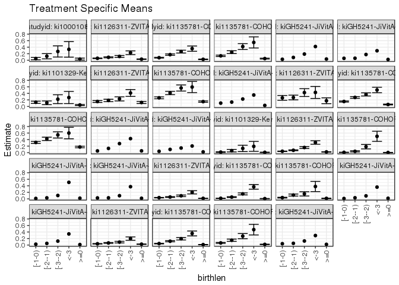

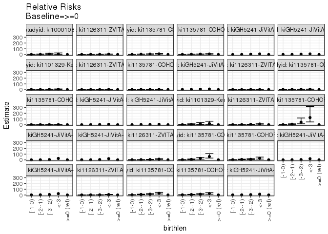

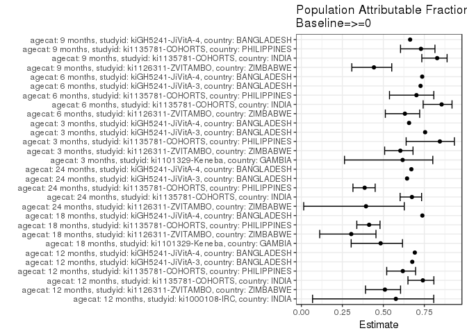

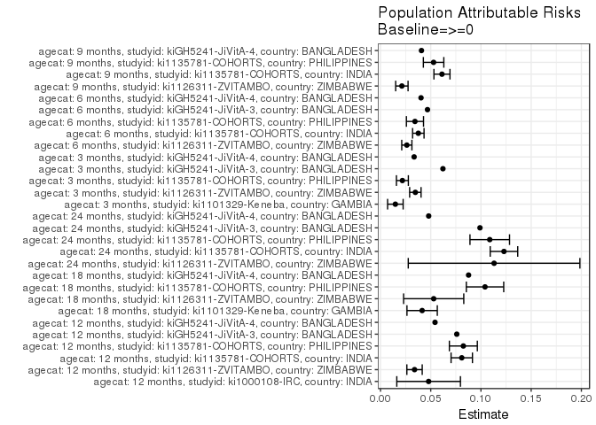

## Results Table

### Parameter: TSM

| agecat | studyid | country | intervention_level | baseline_level | estimate | ci_lower | ci_upper |
| --- | --- | --- | --- | --- | --- | --- | --- |
| 3 months | ki1101329-Keneba | GAMBIA | >=0 | NA | 0.0091623 | 0.0024037 | 0.0159209 |
| 3 months | ki1101329-Keneba | GAMBIA | <-3 | NA | 0.1923077 | 0.0407647 | 0.3438507 |
| 3 months | ki1101329-Keneba | GAMBIA | [-3–2) | NA | 0.1304348 | 0.0330771 | 0.2277924 |
| 3 months | ki1101329-Keneba | GAMBIA | [-2–1) | NA | 0.0604027 | 0.0221372 | 0.0986682 |
| 3 months | ki1101329-Keneba | GAMBIA | [-1-0) | NA | 0.0161290 | 0.0042733 | 0.0279848 |
| 3 months | ki1126311-ZVITAMBO | ZIMBABWE | >=0 | NA | 0.0227723 | 0.0174604 | 0.0280842 |
| 3 months | ki1126311-ZVITAMBO | ZIMBABWE | <-3 | NA | 0.3107143 | 0.2565050 | 0.3649235 |
| 3 months | ki1126311-ZVITAMBO | ZIMBABWE | [-3–2) | NA | 0.1575563 | 0.1289234 | 0.1861892 |
| 3 months | ki1126311-ZVITAMBO | ZIMBABWE | [-2–1) | NA | 0.0723606 | 0.0599931 | 0.0847282 |
| 3 months | ki1126311-ZVITAMBO | ZIMBABWE | [-1-0) | NA | 0.0419703 | 0.0352603 | 0.0486803 |
| 3 months | ki1135781-COHORTS | PHILIPPINES | >=0 | NA | 0.0040032 | 0.0005007 | 0.0075057 |
| 3 months | ki1135781-COHORTS | PHILIPPINES | <-3 | NA | 0.5000000 | 0.3450242 | 0.6549758 |
| 3 months | ki1135781-COHORTS | PHILIPPINES | [-3–2) | NA | 0.1825397 | 0.1150790 | 0.2500003 |
| 3 months | ki1135781-COHORTS | PHILIPPINES | [-2–1) | NA | 0.0400000 | 0.0213665 | 0.0586335 |
| 3 months | ki1135781-COHORTS | PHILIPPINES | [-1-0) | NA | 0.0087464 | 0.0030562 | 0.0144365 |
| 3 months | kiGH5241-JiVitA-3 | BANGLADESH | >=0 | NA | 0.0201871 | NA | NA |
| 3 months | kiGH5241-JiVitA-3 | BANGLADESH | <-3 | NA | 0.5057984 | NA | NA |
| 3 months | kiGH5241-JiVitA-3 | BANGLADESH | [-3–2) | NA | 0.1030435 | NA | NA |
| 3 months | kiGH5241-JiVitA-3 | BANGLADESH | [-2–1) | NA | 0.0300474 | NA | NA |
| 3 months | kiGH5241-JiVitA-3 | BANGLADESH | [-1-0) | NA | 0.0123850 | NA | NA |
| 3 months | kiGH5241-JiVitA-4 | BANGLADESH | >=0 | NA | 0.0174825 | NA | NA |
| 3 months | kiGH5241-JiVitA-4 | BANGLADESH | <-3 | NA | 0.3720930 | NA | NA |
| 3 months | kiGH5241-JiVitA-4 | BANGLADESH | [-3–2) | NA | 0.0961538 | NA | NA |
| 3 months | kiGH5241-JiVitA-4 | BANGLADESH | [-2–1) | NA | 0.0307692 | NA | NA |
| 3 months | kiGH5241-JiVitA-4 | BANGLADESH | [-1-0) | NA | 0.0277778 | NA | NA |
| 6 months | ki1126311-ZVITAMBO | ZIMBABWE | >=0 | NA | 0.0152950 | 0.0107046 | 0.0198854 |
| 6 months | ki1126311-ZVITAMBO | ZIMBABWE | <-3 | NA | 0.2008197 | 0.1505501 | 0.2510893 |
| 6 months | ki1126311-ZVITAMBO | ZIMBABWE | [-3–2) | NA | 0.0932358 | 0.0688678 | 0.1176038 |
| 6 months | ki1126311-ZVITAMBO | ZIMBABWE | [-2–1) | NA | 0.0555184 | 0.0439101 | 0.0671267 |
| 6 months | ki1126311-ZVITAMBO | ZIMBABWE | [-1-0) | NA | 0.0363405 | 0.0297915 | 0.0428894 |

[output cut: 115 more lines]

### Parameter: E(Y)

| agecat | studyid | country | intervention_level | baseline_level | estimate | ci_lower | ci_upper |
| --- | --- | --- | --- | --- | --- | --- | --- |
| 3 months | ki1101329-Keneba | GAMBIA | NA | NA | 0.0239605 | 0.0160009 | 0.0319201 |
| 3 months | ki1126311-ZVITAMBO | ZIMBABWE | NA | NA | 0.0574649 | 0.0526695 | 0.0622603 |
| 3 months | ki1135781-COHORTS | PHILIPPINES | NA | NA | 0.0257930 | 0.0199915 | 0.0315944 |
| 3 months | kiGH5241-JiVitA-3 | BANGLADESH | NA | NA | 0.0823393 | NA | NA |
| 3 months | kiGH5241-JiVitA-4 | BANGLADESH | NA | NA | 0.0509479 | NA | NA |
| 6 months | ki1126311-ZVITAMBO | ZIMBABWE | NA | NA | 0.0414983 | 0.0371732 | 0.0458235 |
| 6 months | ki1135781-COHORTS | INDIA | NA | NA | 0.0440170 | 0.0388831 | 0.0491508 |
| 6 months | ki1135781-COHORTS | PHILIPPINES | NA | NA | 0.0488708 | 0.0407385 | 0.0570030 |
| 6 months | kiGH5241-JiVitA-3 | BANGLADESH | NA | NA | 0.0643497 | NA | NA |
| 6 months | kiGH5241-JiVitA-4 | BANGLADESH | NA | NA | 0.0547550 | NA | NA |
| 9 months | ki1126311-ZVITAMBO | ZIMBABWE | NA | NA | 0.0480667 | 0.0432420 | 0.0528914 |
| 9 months | ki1135781-COHORTS | INDIA | NA | NA | 0.0738776 | 0.0668209 | 0.0809344 |
| 9 months | ki1135781-COHORTS | PHILIPPINES | NA | NA | 0.0724584 | 0.0626870 | 0.0822298 |
| 9 months | kiGH5241-JiVitA-4 | BANGLADESH | NA | NA | 0.0614948 | NA | NA |
| 12 months | ki1000108-IRC | INDIA | NA | NA | 0.0831169 | 0.0555058 | 0.1107280 |
| 12 months | ki1126311-ZVITAMBO | ZIMBABWE | NA | NA | 0.0664858 | 0.0604899 | 0.0724816 |
| 12 months | ki1135781-COHORTS | INDIA | NA | NA | 0.1091954 | 0.1002761 | 0.1181147 |
| 12 months | ki1135781-COHORTS | PHILIPPINES | NA | NA | 0.1333333 | 0.1202138 | 0.1464529 |
| 12 months | kiGH5241-JiVitA-3 | BANGLADESH | NA | NA | 0.1123086 | NA | NA |
| 12 months | kiGH5241-JiVitA-4 | BANGLADESH | NA | NA | 0.0784499 | NA | NA |
| 18 months | ki1101329-Keneba | GAMBIA | NA | NA | 0.0857143 | 0.0698023 | 0.1016263 |
| 18 months | ki1126311-ZVITAMBO | ZIMBABWE | NA | NA | 0.1740939 | 0.1559725 | 0.1922153 |
| 18 months | ki1135781-COHORTS | PHILIPPINES | NA | NA | 0.2519084 | 0.2348507 | 0.2689661 |
| 18 months | kiGH5241-JiVitA-4 | BANGLADESH | NA | NA | 0.1188406 | NA | NA |
| 24 months | ki1126311-ZVITAMBO | ZIMBABWE | NA | NA | 0.2869955 | 0.2449663 | 0.3290248 |
| 24 months | ki1135781-COHORTS | INDIA | NA | NA | 0.1823146 | 0.1713461 | 0.1932832 |
| 24 months | ki1135781-COHORTS | PHILIPPINES | NA | NA | 0.2817363 | 0.2638908 | 0.2995817 |
| 24 months | kiGH5241-JiVitA-3 | BANGLADESH | NA | NA | 0.1536260 | NA | NA |
| 24 months | kiGH5241-JiVitA-4 | BANGLADESH | NA | NA | 0.0714967 | NA | NA |

### Parameter: RR

| agecat | studyid | country | intervention_level | baseline_level | estimate | ci_lower | ci_upper |
| --- | --- | --- | --- | --- | --- | --- | --- |
| 3 months | ki1101329-Keneba | GAMBIA | >=0 | >=0 | 1.0000000 | 1.0000000 | 1.000000 |
| 3 months | ki1101329-Keneba | GAMBIA | <-3 | >=0 | 20.9890110 | 7.1320131 | 61.769177 |
| 3 months | ki1101329-Keneba | GAMBIA | [-3–2) | >=0 | 14.2360248 | 4.9846634 | 40.657590 |
| 3 months | ki1101329-Keneba | GAMBIA | [-2–1) | >=0 | 6.5925216 | 2.4932462 | 17.431628 |
| 3 months | ki1101329-Keneba | GAMBIA | [-1-0) | >=0 | 1.7603687 | 0.6213608 | 4.987276 |
| 3 months | ki1126311-ZVITAMBO | ZIMBABWE | >=0 | >=0 | 1.0000000 | 1.0000000 | 1.000000 |
| 3 months | ki1126311-ZVITAMBO | ZIMBABWE | <-3 | >=0 | 13.6444099 | 10.1964490 | 18.258309 |
| 3 months | ki1126311-ZVITAMBO | ZIMBABWE | [-3–2) | >=0 | 6.9187753 | 5.1476486 | 9.299285 |
| 3 months | ki1126311-ZVITAMBO | ZIMBABWE | [-2–1) | >=0 | 3.1775749 | 2.3796198 | 4.243107 |
| 3 months | ki1126311-ZVITAMBO | ZIMBABWE | [-1-0) | >=0 | 1.8430423 | 1.3890573 | 2.445403 |
| 3 months | ki1135781-COHORTS | PHILIPPINES | >=0 | >=0 | 1.0000000 | 1.0000000 | 1.000000 |
| 3 months | ki1135781-COHORTS | PHILIPPINES | <-3 | >=0 | 124.9000000 | 49.3686040 | 315.990503 |
| 3 months | ki1135781-COHORTS | PHILIPPINES | [-3–2) | >=0 | 45.5984127 | 17.6388362 | 117.877122 |
| 3 months | ki1135781-COHORTS | PHILIPPINES | [-2–1) | >=0 | 9.9920000 | 3.7083218 | 26.923247 |
| 3 months | ki1135781-COHORTS | PHILIPPINES | [-1-0) | >=0 | 2.1848397 | 0.7343682 | 6.500178 |
| 3 months | kiGH5241-JiVitA-3 | BANGLADESH | >=0 | >=0 | 1.0000000 | NA | NA |
| 3 months | kiGH5241-JiVitA-3 | BANGLADESH | <-3 | >=0 | 25.0555253 | NA | NA |
| 3 months | kiGH5241-JiVitA-3 | BANGLADESH | [-3–2) | >=0 | 5.1044221 | NA | NA |
| 3 months | kiGH5241-JiVitA-3 | BANGLADESH | [-2–1) | >=0 | 1.4884477 | NA | NA |
| 3 months | kiGH5241-JiVitA-3 | BANGLADESH | [-1-0) | >=0 | 0.6135104 | NA | NA |
| 3 months | kiGH5241-JiVitA-4 | BANGLADESH | >=0 | >=0 | 1.0000000 | NA | NA |
| 3 months | kiGH5241-JiVitA-4 | BANGLADESH | <-3 | >=0 | 21.2837199 | NA | NA |
| 3 months | kiGH5241-JiVitA-4 | BANGLADESH | [-3–2) | >=0 | 5.4999997 | NA | NA |
| 3 months | kiGH5241-JiVitA-4 | BANGLADESH | [-2–1) | >=0 | 1.7599999 | NA | NA |
| 3 months | kiGH5241-JiVitA-4 | BANGLADESH | [-1-0) | >=0 | 1.5888888 | NA | NA |
| 6 months | ki1126311-ZVITAMBO | ZIMBABWE | >=0 | >=0 | 1.0000000 | 1.0000000 | 1.000000 |
| 6 months | ki1126311-ZVITAMBO | ZIMBABWE | <-3 | >=0 | 13.1297782 | 8.8823634 | 19.408244 |
| 6 months | ki1126311-ZVITAMBO | ZIMBABWE | [-3–2) | >=0 | 6.0958460 | 4.0944529 | 9.075532 |
| 6 months | ki1126311-ZVITAMBO | ZIMBABWE | [-2–1) | >=0 | 3.6298446 | 2.5178654 | 5.232914 |
| 6 months | ki1126311-ZVITAMBO | ZIMBABWE | [-1-0) | >=0 | 2.3759728 | 1.6741959 | 3.371915 |

[output cut: 115 more lines]

### Parameter: PAR

| agecat | studyid | country | intervention_level | baseline_level | estimate | ci_lower | ci_upper |
| --- | --- | --- | --- | --- | --- | --- | --- |
| 3 months | ki1101329-Keneba | GAMBIA | >=0 | NA | 0.0147982 | 0.0070622 | 0.0225343 |
| 3 months | ki1126311-ZVITAMBO | ZIMBABWE | >=0 | NA | 0.0346926 | 0.0290079 | 0.0403773 |
| 3 months | ki1135781-COHORTS | PHILIPPINES | >=0 | NA | 0.0217898 | 0.0158532 | 0.0277263 |
| 3 months | kiGH5241-JiVitA-3 | BANGLADESH | >=0 | NA | 0.0621522 | NA | NA |
| 3 months | kiGH5241-JiVitA-4 | BANGLADESH | >=0 | NA | 0.0334653 | NA | NA |
| 6 months | ki1126311-ZVITAMBO | ZIMBABWE | >=0 | NA | 0.0262034 | 0.0211425 | 0.0312642 |
| 6 months | ki1135781-COHORTS | INDIA | >=0 | NA | 0.0376549 | 0.0319553 | 0.0433545 |
| 6 months | ki1135781-COHORTS | PHILIPPINES | >=0 | NA | 0.0343035 | 0.0257855 | 0.0428215 |
| 6 months | kiGH5241-JiVitA-3 | BANGLADESH | >=0 | NA | 0.0467802 | NA | NA |
| 6 months | kiGH5241-JiVitA-4 | BANGLADESH | >=0 | NA | 0.0403458 | NA | NA |
| 9 months | ki1126311-ZVITAMBO | ZIMBABWE | >=0 | NA | 0.0212737 | 0.0151059 | 0.0274414 |
| 9 months | ki1135781-COHORTS | INDIA | >=0 | NA | 0.0611856 | 0.0532032 | 0.0691680 |
| 9 months | ki1135781-COHORTS | PHILIPPINES | >=0 | NA | 0.0528506 | 0.0426605 | 0.0630407 |
| 9 months | kiGH5241-JiVitA-4 | BANGLADESH | >=0 | NA | 0.0407847 | NA | NA |
| 12 months | ki1000108-IRC | INDIA | >=0 | NA | 0.0479056 | 0.0162182 | 0.0795931 |
| 12 months | ki1126311-ZVITAMBO | ZIMBABWE | >=0 | NA | 0.0338823 | 0.0262417 | 0.0415230 |
| 12 months | ki1135781-COHORTS | INDIA | >=0 | NA | 0.0809005 | 0.0702590 | 0.0915420 |
| 12 months | ki1135781-COHORTS | PHILIPPINES | >=0 | NA | 0.0824859 | 0.0685648 | 0.0964070 |
| 12 months | kiGH5241-JiVitA-3 | BANGLADESH | >=0 | NA | 0.0759449 | NA | NA |
| 12 months | kiGH5241-JiVitA-4 | BANGLADESH | >=0 | NA | 0.0542807 | NA | NA |
| 18 months | ki1101329-Keneba | GAMBIA | >=0 | NA | 0.0414395 | 0.0263350 | 0.0565440 |
| 18 months | ki1126311-ZVITAMBO | ZIMBABWE | >=0 | NA | 0.0529599 | 0.0230139 | 0.0829058 |
| 18 months | ki1135781-COHORTS | PHILIPPINES | >=0 | NA | 0.1040663 | 0.0854513 | 0.1226813 |
| 18 months | kiGH5241-JiVitA-4 | BANGLADESH | >=0 | NA | 0.0876879 | NA | NA |
| 24 months | ki1126311-ZVITAMBO | ZIMBABWE | >=0 | NA | 0.1130825 | 0.0276281 | 0.1985369 |
| 24 months | ki1135781-COHORTS | INDIA | >=0 | NA | 0.1229305 | 0.1092375 | 0.1366234 |
| 24 months | ki1135781-COHORTS | PHILIPPINES | >=0 | NA | 0.1087684 | 0.0890751 | 0.1284617 |
| 24 months | kiGH5241-JiVitA-3 | BANGLADESH | >=0 | NA | 0.0990283 | NA | NA |
| 24 months | kiGH5241-JiVitA-4 | BANGLADESH | >=0 | NA | 0.0479673 | NA | NA |

### Parameter: PAF

| agecat | studyid | country | intervention_level | baseline_level | estimate | ci_lower | ci_upper |
| --- | --- | --- | --- | --- | --- | --- | --- |
| 3 months | ki1101329-Keneba | GAMBIA | >=0 | NA | 0.6176086 | 0.2630503 | 0.8015832 |
| 3 months | ki1126311-ZVITAMBO | ZIMBABWE | >=0 | NA | 0.6037186 | 0.5078567 | 0.6809081 |
| 3 months | ki1135781-COHORTS | PHILIPPINES | >=0 | NA | 0.8447948 | 0.6389840 | 0.9332753 |
| 3 months | kiGH5241-JiVitA-3 | BANGLADESH | >=0 | NA | 0.7548303 | NA | NA |
| 3 months | kiGH5241-JiVitA-4 | BANGLADESH | >=0 | NA | 0.6568548 | NA | NA |
| 6 months | ki1126311-ZVITAMBO | ZIMBABWE | >=0 | NA | 0.6314316 | 0.5121459 | 0.7215507 |
| 6 months | ki1135781-COHORTS | INDIA | >=0 | NA | 0.8554634 | 0.7427472 | 0.9187926 |
| 6 months | ki1135781-COHORTS | PHILIPPINES | >=0 | NA | 0.7019228 | 0.5374514 | 0.8079121 |
| 6 months | kiGH5241-JiVitA-3 | BANGLADESH | >=0 | NA | 0.7269679 | NA | NA |
| 6 months | kiGH5241-JiVitA-4 | BANGLADESH | >=0 | NA | 0.7368421 | NA | NA |
| 9 months | ki1126311-ZVITAMBO | ZIMBABWE | >=0 | NA | 0.4425859 | 0.3076452 | 0.5512266 |
| 9 months | ki1135781-COHORTS | INDIA | >=0 | NA | 0.8282017 | 0.7345477 | 0.8888137 |
| 9 months | ki1135781-COHORTS | PHILIPPINES | >=0 | NA | 0.7293918 | 0.6047381 | 0.8147334 |
| 9 months | kiGH5241-JiVitA-4 | BANGLADESH | >=0 | NA | 0.6632226 | NA | NA |
| 12 months | ki1000108-IRC | INDIA | >=0 | NA | 0.5763644 | 0.0682273 | 0.8073918 |
| 12 months | ki1126311-ZVITAMBO | ZIMBABWE | >=0 | NA | 0.5096182 | 0.3912521 | 0.6049689 |
| 12 months | ki1135781-COHORTS | INDIA | >=0 | NA | 0.7408786 | 0.6500085 | 0.8081557 |
| 12 months | ki1135781-COHORTS | PHILIPPINES | >=0 | NA | 0.6186441 | 0.5204777 | 0.6967141 |
| 12 months | kiGH5241-JiVitA-3 | BANGLADESH | >=0 | NA | 0.6762167 | NA | NA |
| 12 months | kiGH5241-JiVitA-4 | BANGLADESH | >=0 | NA | 0.6919157 | NA | NA |
| 18 months | ki1101329-Keneba | GAMBIA | >=0 | NA | 0.4834605 | 0.3037696 | 0.6167749 |
| 18 months | ki1126311-ZVITAMBO | ZIMBABWE | >=0 | NA | 0.3042029 | 0.1117141 | 0.4549799 |
| 18 months | ki1135781-COHORTS | PHILIPPINES | >=0 | NA | 0.4131118 | 0.3380658 | 0.4796496 |
| 18 months | kiGH5241-JiVitA-4 | BANGLADESH | >=0 | NA | 0.7378619 | NA | NA |
| 24 months | ki1126311-ZVITAMBO | ZIMBABWE | >=0 | NA | 0.3940217 | 0.0141952 | 0.6275027 |
| 24 months | ki1135781-COHORTS | INDIA | >=0 | NA | 0.6742765 | 0.6022494 | 0.7332605 |
| 24 months | ki1135781-COHORTS | PHILIPPINES | >=0 | NA | 0.3860646 | 0.3145510 | 0.4501172 |
| 24 months | kiGH5241-JiVitA-3 | BANGLADESH | >=0 | NA | 0.6446063 | NA | NA |
| 24 months | kiGH5241-JiVitA-4 | BANGLADESH | >=0 | NA | 0.6709020 | NA | NA |